# CART and Cluster analysis

This is a short attempt to use SIMD data to demonstrate CARTs, Cluster Analyses etc.

# CART

Classification and regression trees try to classify observations into discrete groups based on the characteristics of variables. They are predictive rather than descriptive, unlike cluster analysis, as the discrete groups are known beforehand, and predicted can be compared against actual groups. Through this they can be helpful for getting a sense of the main features that distinguish different groups, and so perhaps the discriminatory power (statistical usefulness) of different variables available to you. In this example they will try to classify datazones into council areas based on various 2016 SIMD ranks, and population sizes.

```r
# Using examples from
#http://www.statmethods.net/advstats/cart.html
cart_model <- rpart(Council_area ~ Total_population + Working_age_population + Overall_SIMD16_rank + Income_domain_2016_rank + Housing_domain_2016_rank + Access_domain_2016_rank, data = simd_2016, method = "class")
printcp(cart_model) # display the results
```

```
Classification tree:
rpart(formula = Council_area ~ Total_population + Working_age_population +
    Overall_SIMD16_rank + Income_domain_2016_rank + Housing_domain_2016_rank +
    Access_domain_2016_rank, data = simd_2016, method = "class")

Variables actually used in tree construction:
[1] Access_domain_2016_rank  Housing_domain_2016_rank Overall_SIMD16_rank

Root node error: 6230/6976 = 0.89306

n= 6976

        CP nsplit rel error  xerror      xstd
1 0.036276      0   1.00000 1.00000 0.0041431
2 0.018299      1   0.96372 0.96388 0.0046406
3 0.014848      2   0.94543 0.94607 0.0048532
4 0.010000      4   0.91573 0.92456 0.0050861
```

```r
plotcp(cart_model) # visualize cross-validation results
summary(cart_model) # detailed summary of splits
```

[output not shown]

```
Call:
rpart(formula = Council_area ~ Total_population + Working_age_population +
    Overall_SIMD16_rank + Income_domain_2016_rank + Housing_domain_2016_rank +
    Access_domain_2016_rank, data = simd_2016, method = "class")
  n= 6976

          CP nsplit rel error    xerror        xstd
1 0.03627608      0 1.0000000 1.0000000 0.004143069
2 0.01829856      1 0.9637239 0.9638844 0.004640608
3 0.01484751      2 0.9454254 0.9460674 0.004853191
4 0.01000000      4 0.9157303 0.9245586 0.005086122

Variable importance
Housing_domain_2016_rank      Overall_SIMD16_rank  Access_domain_2016_rank  Income_domain_2016_rank
                      56                       20                       13                        9
  Working_age_population
                       2

Node number 1: 6976 observations,    complexity param=0.03627608
  predicted class=Glasgow City       expected loss=0.8930619  P(node) =1
    class counts:   283   340   155   125   597    72   201   188   163   130   132   122   214   494   746   312   114   115   126    36   186   447    29   186   225   143    30   153   431   121   121   239
   probabilities: 0.041 0.049 0.022 0.018 0.086 0.010 0.029 0.027 0.023 0.019 0.019 0.017 0.031 0.071 0.107 0.045 0.016 0.016 0.018 0.005 0.027 0.064 0.004 0.027 0.032 0.020 0.004 0.022 0.062 0.017 0.017 0.034
  left son=2 (1133 obs) right son=3 (5843 obs)
  Primary splits:
      Housing_domain_2016_rank < 1133.5  to the left,  improve=178.86070, (0 missing)
      Income_domain_2016_rank  < 961.5   to the right, improve= 65.76284, (0 missing)
      Overall_SIMD16_rank      < 1028.5  to the right, improve= 63.02585, (0 missing)
      Access_domain_2016_rank  < 2713.5  to the right, improve= 54.21518, (0 missing)
      Working_age_population   < 632.5   to the right, improve= 35.13885, (0 missing)
  Surrogate splits:
      Overall_SIMD16_rank     < 440.5   to the left,  agree=0.860, adj=0.138, (0 split)
      Income_domain_2016_rank < 466.5   to the left,  agree=0.857, adj=0.118, (0 split)
      Access_domain_2016_rank < 6739.5  to the right, agree=0.847, adj=0.059, (0 split)
      Working_age_population  < 780.5   to the right, agree=0.845, adj=0.044, (0 split)
      Total_population        < 324.5   to the left,  agree=0.838, adj=0.005, (0 split)

Node number 2: 1133 observations
  predicted class=Glasgow City       expected loss=0.5710503  P(node) =0.162414
    class counts:    82     6     4     6   220     4     3    68     3     3     6     4     2     8   486     7    24     5     1     0     8    65     2    13    41     0     0     6    34     9    10     3
   probabilities: 0.072 0.005 0.004 0.005 0.194 0.004 0.003 0.060 0.003 0.003 0.005 0.004 0.002 0.007 0.429 0.006 0.021 0.004 0.001 0.000 0.007 0.057 0.002 0.011 0.036 0.000 0.000 0.005 0.030 0.008 0.009 0.003
```

[output cut: 51 more lines]

```
      Working_age_population   < 512.5   to the right, improve= 6.210325, (0 missing)
  Surrogate splits:
      Overall_SIMD16_rank     < 1914.5  to the left,  agree=0.795, adj=0.258, (0 split)
      Income_domain_2016_rank < 1561    to the left,  agree=0.788, adj=0.233, (0 split)
      Access_domain_2016_rank < 6905.5  to the right, agree=0.724, adj=0.003, (0 split)

Node number 30: 1335 observations
  predicted class=North Lanarkshire  expected loss=0.8838951  P(node) =0.1913704
    class counts:    67    20    27    29    99    15    25    45    38    18    30    13    39    57   148    41    47    26    14     0    47   155     3    24    57    17     5    19    98    14    58    40
   probabilities: 0.050 0.015 0.020 0.022 0.074 0.011 0.019 0.034 0.028 0.013 0.022 0.010 0.029 0.043 0.111 0.031 0.035 0.019 0.010 0.000 0.035 0.116 0.002 0.018 0.043 0.013 0.004 0.014 0.073 0.010 0.043 0.030

Node number 31: 3493 observations
  predicted class=Fife               expected loss=0.8866304  P(node) =0.5007167
    class counts:    78   178    90    58   146    50   114    68   105    89    77    73   160   396    96   159    36    75    83    15   121   218     9   103   117    88     8   113   270    68    53   179
   probabilities: 0.022 0.051 0.026 0.017 0.042 0.014 0.033 0.019 0.030 0.025 0.022 0.021 0.046 0.113 0.027 0.046 0.010 0.021 0.024 0.004 0.035 0.062 0.003 0.029 0.033 0.025 0.002 0.032 0.077 0.019 0.015 0.051
```

```r
# plot tree
prp(cart_model, uniform=F,
    main="Classification Tree for LAs based on SIMD characteristics",
    clip.right.labs = F, varlen = 0)
```

```r
#text(cart_model, use.n=F, all=F)
```

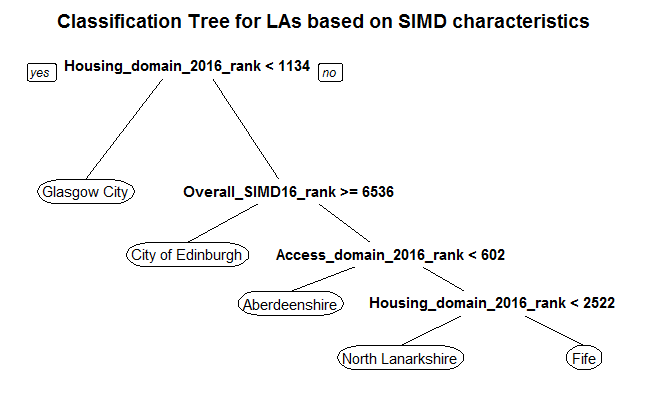

```r
# plot tree
prp(cart_model, uniform=F,
    main="Classification Tree for LAs based on SIMD characteristics",
    clip.right.labs = F, varlen = 0)
```

```r
#text(cart_model, use.n=F, all=F)
```

This is suggesting that the housing domain rank is the most useful single indicator for identifying one c local authority area, namely Glasgow city. If the rank in the housing domain is below 1134, then it predicts the datazone is in Glasgow City. Then, it suggests that if an areas has an overall SIMD rank above 6536 (there are now 6976 2011 datazones, up from 6505 datazones based on the 2001 census), then predict City of Edinburgh. Then, if the access domain rank is less than 602, predict Aberdeenshire, and so on.

```r
printcp(cart_model)
```

```
Classification tree:
rpart(formula = Council_area ~ Total_population + Working_age_population +
    Overall_SIMD16_rank + Income_domain_2016_rank + Housing_domain_2016_rank +
    Access_domain_2016_rank, data = simd_2016, method = "class")

Variables actually used in tree construction:
[1] Access_domain_2016_rank  Housing_domain_2016_rank Overall_SIMD16_rank

Root node error: 6230/6976 = 0.89306

n= 6976

        CP nsplit rel error  xerror      xstd
1 0.036276      0   1.00000 1.00000 0.0041431
2 0.018299      1   0.96372 0.96388 0.0046406
3 0.014848      2   0.94543 0.94607 0.0048532
4 0.010000      4   0.91573 0.92456 0.0050861
```